# DQ1

# Q1 Question

Have fine particle (PM2.5) outdoor air pollution decreased between 1999 and 2012?

# Q2 Data Import and Cleaning

## Import the data

- Download the two data files into the working directory from [here](https://unsw-my.sharepoint.com/:f:/g/personal/z3509662_ad_unsw_edu_au/EnKC86EULN5Ji7Z0ig6b7j4BE-HJT5QgP_--tvc10HeBGg?e=5SQlIJ), which are for the two years, 1999 and 2012
- Import the data using read.delim with the delimiter “|”.
- Skip the first two rows since it is not data values - duplicate column names
- Since missing values are indicated by ““, set na =””
- Attach the columns names back to the dataset by storing column names in a vector and then setting col.names = cnames

Check the head of data to have a look at the data and check it was imported properly

```
##   X..RD Action.Code State.Code County.Code Site.ID Parameter POC
## 1    RD           I          1          27       1     88101   1
## 2    RD           I          1          27       1     88101   1
## 3    RD           I          1          27       1     88101   1
## 4    RD           I          1          27       1     88101   1
## 5    RD           I          1          27       1     88101   1
## 6    RD           I          1          27       1     88101   1
##   Sample.Duration Unit Method     Date Start.Time Sample.Value Null.Data.Code
## 1               7  105    120 19990103      00:00           NA             AS
## 2               7  105    120 19990106      00:00           NA             AS
## 3               7  105    120 19990109      00:00           NA             AS
## 4               7  105    120 19990112      00:00        8.841           <NA>
## 5               7  105    120 19990115      00:00       14.920           <NA>
## 6               7  105    120 19990118      00:00        3.878           <NA>
##   Sampling.Frequency Monitor.Protocol..MP..ID Qualifier...1 Qualifier...2
```

[output cut: 27 more lines]

```
##   X..RD Action.Code State.Code County.Code Site.ID Parameter POC
## 1    RD           I          1           3      10     88101   1
## 2    RD           I          1           3      10     88101   1
## 3    RD           I          1           3      10     88101   1
## 4    RD           I          1           3      10     88101   1
## 5    RD           I          1           3      10     88101   1
## 6    RD           I          1           3      10     88101   1
##   Sample.Duration Unit Method     Date Start.Time Sample.Value Null.Data.Code
## 1               7  105    118 20120104      00:00          9.0           <NA>
## 2               7  105    118 20120107      00:00          6.5           <NA>
## 3               7  105    118 20120110      00:00          7.0           <NA>
## 4               7  105    118 20120113      00:00          5.8           <NA>
## 5               7  105    118 20120116      00:00          8.0           <NA>
## 6               7  105    118 20120119      00:00          7.9           <NA>
##   Sampling.Frequency Monitor.Protocol..MP..ID Qualifier...1 Qualifier...2
```

[output cut: 27 more lines]

Check proportion of missing values - since proportion is low, we will ignore missing values and remove those rows

```
## [1] 0.1125683
```

```
## [1] 0.05607201
```

Check if there are any duplicate rows

```
## [1] 0
```

```
## [1] 0
```

Check that Sample Values make sense - only 2012 has 2% of data with negative values whilst 1999 doesn’t

```
## [1] 0.02029768
```

```
## [1] 0
```

## Data Cleaning

The following data cleaning steps were then applied: - Remove the first row as it is the column names duplicated - Remove the last row as it identifies the number of rows and contains no data - Merge the two datasets since the columns are consistent and data information is provided by the ‘Date’ variable - Convert Date from character to date value - Split Date into a Year and Month categorical Variable - Convert character variables into a categorical Variable including State.Code, County.Code, Site.ID, Method and POC

## Check the data

|  | Unique Values | Missing Values |
| --- | --- | --- |
| X..RD | 1 | 0 |
| Action.Code | 1 | 0 |
| State.Code | 53 | 0 |
| County.Code | 133 | 0 |
| Site.ID | 275 | 0 |
| Parameter | 1 | 0 |
| POC | 9 | 0 |
| Sample.Duration | 2 | 0 |
| Unit | 2 | 0 |
| Method | 19 | 0 |
| Start.Time | 41 | 0 |
| Sample.Value | 22102 | 0 |
| Null.Data.Code | 1 | 1335356 |
| Sampling.Frequency | 7 | 1179717 |
| Monitor.Protocol..MP..ID | 1 | 1335356 |
| Qualifier…1 | 40 | 1304877 |
| Qualifier…2 | 4 | 1335288 |
| Qualifier…3 | 2 | 1335355 |
| Qualifier…4 | 1 | 1335356 |
| Qualifier…5 | 1 | 1335356 |
| Qualifier…6 | 1 | 1335356 |
| Qualifier…7 | 1 | 1335356 |
| Qualifier…8 | 1 | 1335356 |
| Qualifier…9 | 1 | 1335356 |
| Qualifier…10 | 1 | 1335356 |
| Alternate.Method.Detectable.Limit | 3 | 1316237 |
| Uncertainty | 1 | 1335356 |
| Year | 2 | 0 |
| Month | 12 | 0 |

## Removal of Variables and NA rows

# Q3 Data Issues

- Missing values
  - The proportion of data with missing values for Sample.Value is low, 0.1125683 for 1999 and 0.05607201 for 2012.
  - I have ignored the missing values and removed these rows
- Variables with only NA values or only 1 unique value was removed
- Variables that were irrelevant to the question was removed as they didn’t provide relevant information
- Some rows had Sample Value being null or negative
  - These rows were ignored and removed as they are not valid data

# Q4 What is your answer to your question? And how do you reach that answer?

## Overall Boxplot

The boxplot reveals differences in distribution between the two years. It appears that on average, the levels of PM in 2012 are lower than they were in 1999. It can also be seen that there is greater variation in PM in 2012.

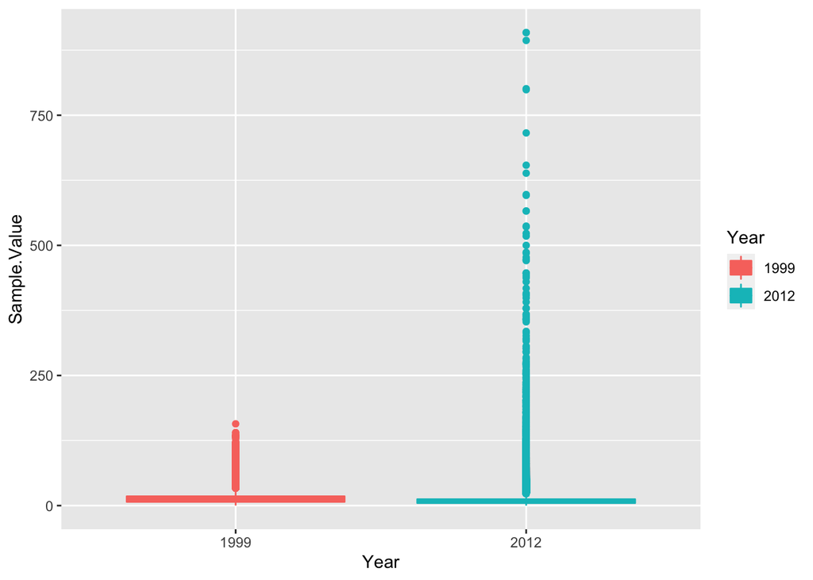

## Distribution Density by Year

Similar to our findings above, it appears that whilst the mean of the 2012 data is lower, there is greater variance in PM levels.

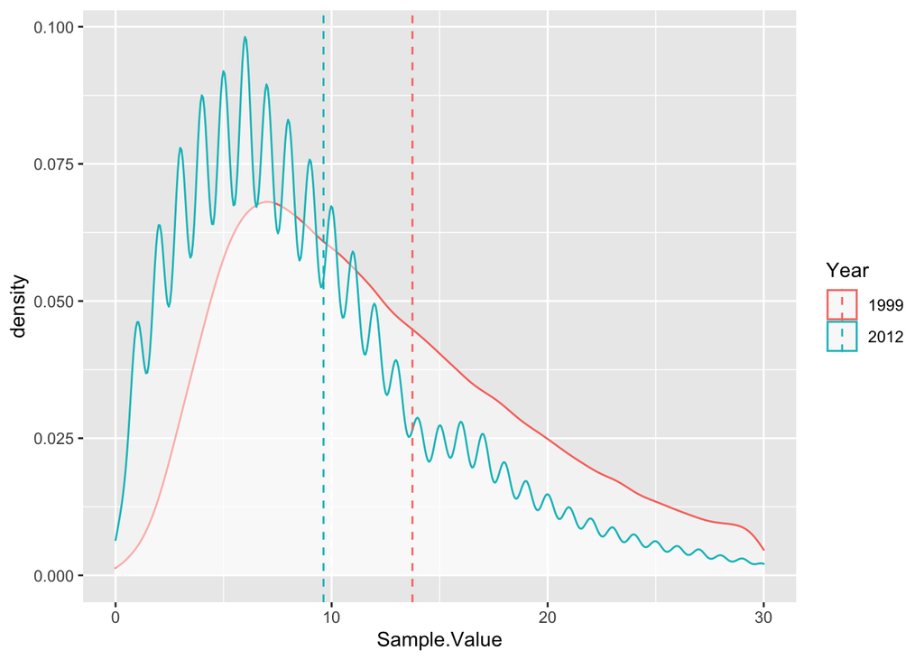

## Mean PM Levels by Month

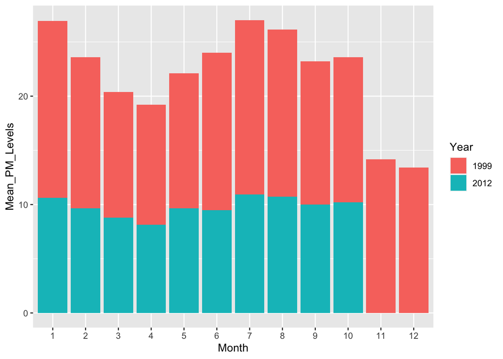

## Mean PM Levels by State

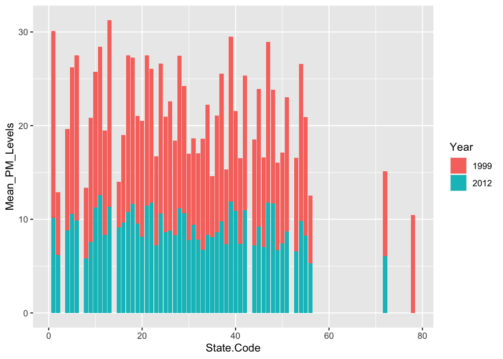

# Q5 Follow up questions

- Whether the level of air pollution is also affected by and whether this affects the comparability of data:
  - Method of collection
  - Duration of measurement
- Improve visualisation by depicting levels of air pollution of a map of US which may reveal any geographical patterns
- Whether the Clean Air Act is the only influence on lower air pollution levels? Perhaps other laws / improvement in technology?